# Análise de Emoções

Gilberto Rodrigo Radecki

2024-09-11

## Resumo

Aplicação de técnicas de Processamento de Linguagem Natural para análise de Emoções em avaliações de produtos e serviços no idioma português.

**A análise de emoções pode complementar a análise de sentimentos, permitindo não apenas avaliar se uma avaliação é positiva, negativa ou neutra, como também verificar quais sentimentos estão associados à experiência do cliente.**

## Análise de Emoções

A análise de emoções e a análise de sentimentos são subcampos do Processamento de Linguagem Natural que, embora frequentemente usadas de forma intercambiável, têm diferenças importantes em suas abordagens, objetivos e métodos.

### Análise de Sentimentos

A análise de sentimentos é um processo que visa identificar, extrair e quantificar a opinião expressa em um texto. Normalmente, esta análise categoriza o sentimento em classes gerais, como positivo, negativo ou neutro. Em alguns casos, ela pode ir além, identificando o grau de positividade ou negatividade (por exemplo, “muito positivo” ou “ligeiramente negativo”). Essa técnica é amplamente usada em contextos como em análise de avaliações de produtos ou serviços, monitoramento de mídia social e análise de feedback de clientes. O foco principal da análise de sentimentos é detectar a polaridade da opinião expressa e entender a direção geral da emoção, sem necessariamente capturar a complexidade das emoções envolvidas.

### Objetivos

O objetivo desse trabalho é demonstrar como a análise de emoções pode ser aplicada no contexto da avaliação de produtos e serviços.

Os dados utilizados neste exemplo são compostos de avaliações de clientes de uma loja de departamentos muito famosa aqui no Brasil.

```
install.packages("syuzhet") # Responsável pela análise de emoções e sentimentos
install.packages("udpipe") # Pacote com funções úteis de processamento de linguagem natural, POS tagging, tokenização e lematização, etc.
install.packages("fmsb") # Para plotar o radar de emoções
library(syuzhet)
library(udpipe)
library(fmsb)
# Fazer o download do modelo de língua portuguesa
pm <- udpipe_download_model(language = "portuguese-bosque")
# Lendo os dados
data <- read.csv("b2w.csv",header = T,sep = ",",encoding = "utf-8")
# Carregando o modelo de língua portuguesa
up_ptmodel <- udpipe_load_model(file=pm$file_model)
# Selecionando um texto de exemplo
txt <- data[t,2]
# Removendo a pontuação
txt <- gsub('[[:punct:] ]+',' ',txt)
# Realizando anotações - lematização, tokenização, pos tagging e features
notes <- udpipe_annotate(up_ptmodel, x=txt)
notes <- as.data.frame(notes)
# Vou aplicar a função get_nrc_sentiments sobre os lemas do texto de exemplo
lemas <- paste(notes$lemma, collapse = " ")
# Aplicando a análise de sentimentos
sent <- get_nrc_sentiment(lemas, language = "portuguese")
# Separando as duas últimas colunas do data frame
scores <- sent[,9:10]
rownames(scores) <- "Qtde."
sent <- sent[,1:8]
colnames(sent) <- c("Raiva", "Ansiedade", "Nojo", "Medo", "Alegria", "Tristeza", "Surpresa", "Confiança")
# Construindo um gráfico de sentimentos. Para isso, precisamos adicionar valores mínimos
# e máximos ao data frame de sentimentos
sent <- rbind(rep(6,8) , rep(0,8) , sent)
radarchart(sent,
           pcol = "green",
           seg = size,
           plwd = 4,
           cglcol = "grey",
           cglty = 1,
           axislabcol = "grey",
           title = "Radar de Emoções")
```

### Resultados

*Entrega dentro do prazo recomendo ótimo produto Não irão se arrepender*

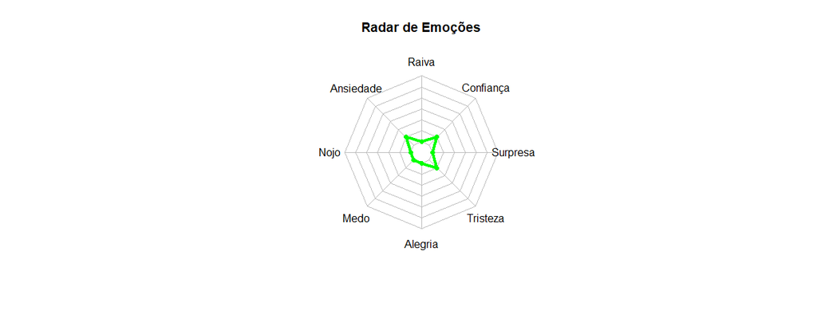

*Balcão bonito Entrega no prazo Material frágil Veio faltando parafusos para fixação do tampo assim como faltou a proteção cor preta atrás do tampo que aparece na imagem Montagem fácil mas o manual de instruções poderia ser mais completo Não recomendo pela falta dos parafusos e da proteção*

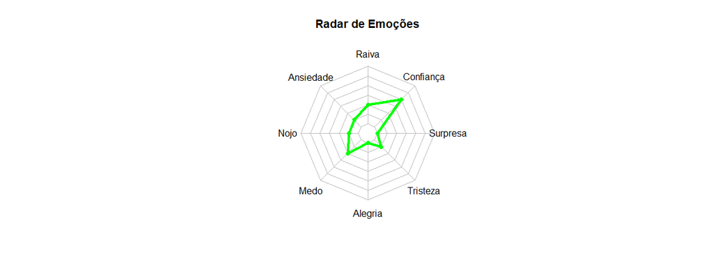

*Bem macio e felpudo recomendo Preço imbatível e entrega rápida Compraria outro quando precisar*

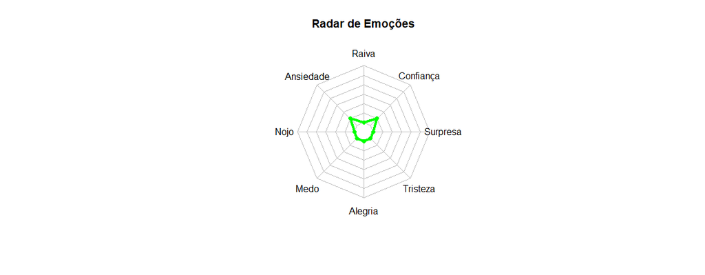

*O parceiro das Lojas Americanas Tudo House RP Tudogaz enviou o produto mal embalado com o gabinete arranhado sem lacres de entrada com cano de exaustão amassado o gabinete arranhado e faltando o manual A aparência estava tão ruim que a concessionária autorizada recusou se a instalar o aquecedor Já pedi o cancelamento da compra e estou aguardando a burocracia do site para reaver o que paguei Recomendo o produto tanto que já comprei outro idêntico em outra loja mas advirto os clientes a evitarem comprar nesse parceiro das Americanas*

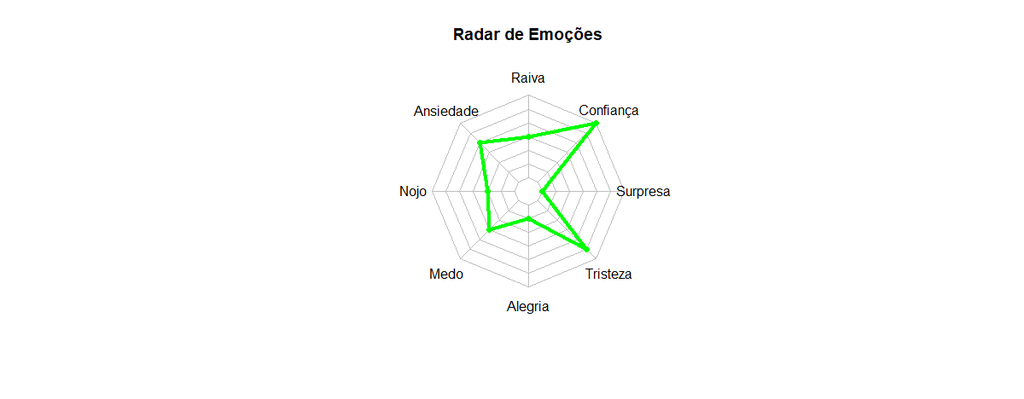

*Passei pra dizer que podem comprar que chegou bem protegido é dois dias antes do previsto*

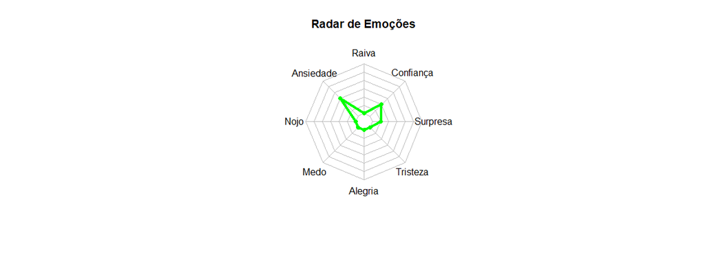

## Conclusão

A análise de emoções pode complementar a análise de sentimentos, permitindo não apenas avaliar se uma avaliação é positiva, negativa ou neutra, como também verificar quais sentimentos estão associados à experiência do clente.